# assignment 10

2022-12-9

# load packages

```r
library(tidyverse)
library(ggthemes)
library(rstatix)
library(ggpubr)
```

# download data into a dataframe called “assignment10”

#importing data

```r
assignment10 = read_csv("a10_data.csv")
```

#Yes, I can load the file

# Descriptives

```r
assignment10 %>%
  group_by(subject, accessibility, distinctiveness) %>%
  # or use group_by(subject, typeoftrial) %>%
  count()
```

```
## # A tibble: 269 × 4
## # Groups:   subject, accessibility, distinctiveness [269]
##    subject accessibility distinctiveness     n
##      <dbl> <chr>         <chr>           <int>
##  1     196 <NA>          <NA>                1
##  2    1533 high          high               60
##  3    1533 high          low                60
##  4    1533 low           high               60
##  5    1533 low           low                60
##  6    1533 prac          prac               12
##  7    1533 <NA>          <NA>               28
##  8    1601 high          high               60
##  9    1601 high          low                60
## 10    1601 low           high               60
## # … with 259 more rows
```

```r
length(assignment10 %>% pull(subject) %>% unique())
```

```
## [1] 53
```

#Yes, but it shows n in each condition, so you need to add up n in all four conditions and prac to get the total n. Or use group_by(subject, typeoftrial) instead which shows n of test directly

#I changed ID to subject (ID didn’t exist in data) and lenth to length to debug it, getting a total of 53 participants

#IVs #I can tell from the overall code that there are 2 IVs, accessibility and distinctiveness, each has 2 levels–high or low

# Filtering

```r
main_data = assignment10 %>% filter(!is.na(accessibility)) %>%
  filter(!accessibility %in% "prac")

main_data %>% group_by(subject, accessibility, distinctiveness) %>%
  count()
```

```
## # A tibble: 172 × 4
## # Groups:   subject, accessibility, distinctiveness [172]
##    subject accessibility distinctiveness     n
##      <dbl> <chr>         <chr>           <int>
##  1    1533 high          high               60
##  2    1533 high          low                60
##  3    1533 low           high               60
##  4    1533 low           low                60
##  5    1601 high          high               60
##  6    1601 high          low                60
##  7    1601 low           high               60
##  8    1601 low           low                60
##  9    3324 high          high               60
## 10    3324 high          low                60
## # … with 162 more rows
```

#No, it didn’t filter out the prac tice trials. To debug it, I changed “practice” to “prac”

#Subject ratings

```r
main_data=main_data%>%
  mutate(response = as.numeric(response))
#Subject ratings
subject_rating = main_data %>%
  group_by(subject, accessibility, distinctiveness) %>%
  summarise(mean_rating = mean(response))
```

#No. To debug it, I changed response to numeric values using as.numeric()

#Count and mean_rating

```r
counts = main_data %>%
  group_by(accessibility, distinctiveness) %>%
  count()
#counts is the number of trials in each of the four accessibility-distinctiveness conditions

mean_rating = main_data %>%
  group_by(accessibility, distinctiveness) %>%
  summarise(mean_rating = mean(response),
            sd_rating = sd(response))  %>%
  left_join(counts) %>%
  mutate(SE = sd_rating/n,
    ymin = mean_rating - 1.96*SE,
        ymax = mean_rating + 1.96*SE)
```

#Yes, mean_rating includes the mean rating for each of the four conditions

# Plot

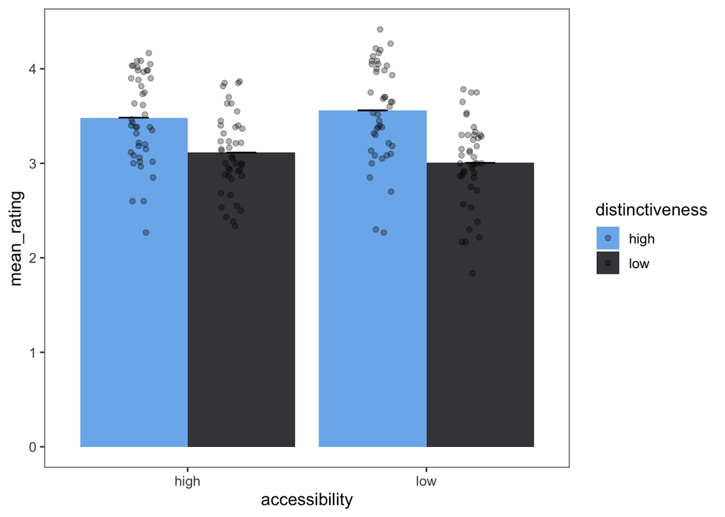

```r
mean_rating %>%
  ggplot(aes(x = accessibility, y = mean_rating,
             group = distinctiveness, fill = distinctiveness))+
  geom_col(position = "dodge")+
  geom_errorbar(aes(ymin = ymin, ymax = ymax),
                width = .25,
                position = position_dodge(width=0.9))+
    geom_point(data = subject_rating, aes(x = accessibility, y = mean_rating,
             group = distinctiveness),
             position = position_jitterdodge(jitter.width = 0.1),
             alpha = 0.3)+

  scale_fill_hc()+
  theme_few()
```

#The plot tells me the mean rating in four accessibility-distinctiveness conditions. #The mean rating is higher when distinctiveness is high than when it’s low regardless of accessibility level. When accessibility is high, mean rating is higher when distinctiveness is high than when it’s low. The same pattern holds when accessibility is low. When distinctiveness is high, mean rating is higher when accessibility is low than when it’s high; But when distinctiveness is low, the mean rating is higher when accessibility is high than when it’s low.

# ANOVA

```r
outliers = subject_rating %>%
  group_by(accessibility, distinctiveness) %>%
  identify_outliers(mean_rating)

 sids = outliers %>% filter(is.extreme == TRUE) %>% pull(subject)

 subject_ratings_new = subject_rating %>% filter(!subject %in% sids)

subject_ratings_new %>%
  group_by(accessibility, distinctiveness) %>%
   shapiro_test(mean_rating)
```

```
## # A tibble: 4 × 5
##   accessibility distinctiveness variable    statistic      p
##   <chr>         <chr>           <chr>           <dbl>  <dbl>
## 1 high          high            mean_rating     0.944 0.0368
## 2 high          low             mean_rating     0.972 0.377
## 3 low           high            mean_rating     0.958 0.115
## 4 low           low             mean_rating     0.960 0.141
```

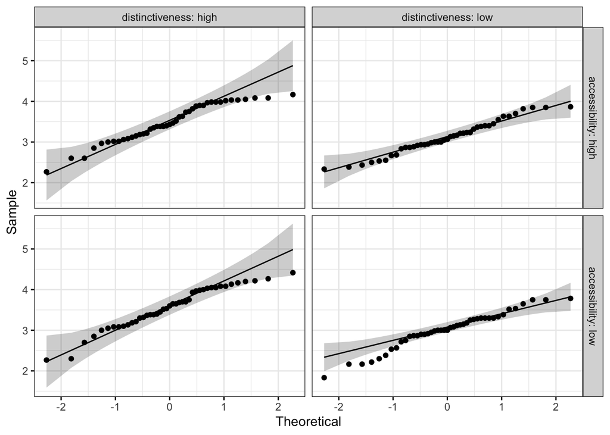

```r
ggqqplot(subject_ratings_new, "mean_rating", ggtheme = theme_bw()) +
  facet_grid(accessibility ~ distinctiveness, labeller = "label_both")
```

```r
#changed rating to mean_rating

## ANOVA for mean ratings as a function of accessibility and distinctiveness
subject_ratings_new=subject_ratings_new%>% ungroup()
#added ungroup()
rm.aov = anova_test(
  data = subject_ratings_new, dv = mean_rating, wid = subject,
  within = c(accessibility, distinctiveness)
  )
#changed RT to mean_rating, ID to subject, andc(weight, pathelength) to c(accessibility, distinctiveness)
get_anova_table(rm.aov)
```

```
## ANOVA Table (type III tests)
##
##                          Effect DFn DFd      F        p p<.05      ges
## 1                 accessibility   1  42  0.416 5.22e-01       0.000261
## 2               distinctiveness   1  42 88.713 6.50e-12     * 0.198000
## 3 accessibility:distinctiveness   1  42 36.348 3.61e-07     * 0.010000
```

#According to the ANOVA test, there is no significant main effect of accessibility as p is larger than 0.05, but there is a significant main effect of distinctiveness and a significant interaction between accessibility and distinctiveness.

```r
## posthoc
subject_ratings_new %>%
  group_by(accessibility) %>%
  anova_test(dv = mean_rating, wid = subject, within = distinctiveness) %>%
  get_anova_table() %>%
  adjust_pvalue(method = "bonferroni")
```

```
## # A tibble: 2 × 9
##   accessibility Effect           DFn   DFd     F        p `p<.05`   ges    p.adj
##   <chr>         <chr>          <dbl> <dbl> <dbl>    <dbl> <chr>   <dbl>    <dbl>
## 1 high          distinctivene…     1    42  61.5 9.28e-10 *       0.146 1.86e- 9
## 2 low           distinctivene…     1    42  99.9 1.14e-12 *       0.247 2.28e-12
```

#I changed group_by(subject) to group_by(accessibility), and pathlength to distinctiveness